# Which Weather Events Affect Public Health And Economy The Most According To NOAA Storm Database (1950 - 2011)

Daren Thomas

5 May 2016

## Synopsis

This Report uses the Storm Database of the U.S. National Oceanic and Atmospheric Administration (NOAA) to identify those weather eventy that create the most harm to public health and the economy. Harm to public health is shown as total fatalities by event type and total injuries by event type. Harm to the economy looks at property damage by event type as well as damage to crops by event type. Data from 1950 to 2011 are considered. An approach to automatically cleaning event type labels in the data is attempted with limited success.

## Data Processing

This project involves exploring the U.S. National Oceanic and Atmospheric Administration’s (NOAA) storm database. This database tracks characteristics of major storms and weather events in the United States, including when and where they occur, as well as estimates of any fatalities, injuries, and property damage.

The data for this assignment come in the form of a comma-separated-value file compressed via the bzip2 algorithm to reduce its size. You can [download the file from the course web site](https://d396qusza40orc.cloudfront.net/repdata%2Fdata%2FStormData.csv.bz2):

```r
noaa.url = "https://d396qusza40orc.cloudfront.net/repdata%2Fdata%2FStormData.csv.bz2"
noaa.bz2 = "storm-data.csv.bz2"
if (! file.exists(noaa.bz2)) {
    download.file(url=noaa.url, destfile=noaa.bz2)
}
noaa <- read.csv(noaa.bz2)
```

After reading, we check the first few rows (there are 902297 ) in the dataset:

```r
dim(noaa)
```

```
## [1] 902297     37
```

```r
head(noaa)
```

```
##   STATE__           BGN_DATE BGN_TIME TIME_ZONE COUNTY COUNTYNAME STATE
## 1       1  4/18/1950 0:00:00     0130       CST     97     MOBILE    AL
## 2       1  4/18/1950 0:00:00     0145       CST      3    BALDWIN    AL
## 3       1  2/20/1951 0:00:00     1600       CST     57    FAYETTE    AL
## 4       1   6/8/1951 0:00:00     0900       CST     89    MADISON    AL
## 5       1 11/15/1951 0:00:00     1500       CST     43    CULLMAN    AL
## 6       1 11/15/1951 0:00:00     2000       CST     77 LAUDERDALE    AL
##    EVTYPE BGN_RANGE BGN_AZI BGN_LOCATI END_DATE END_TIME COUNTY_END
## 1 TORNADO         0                                               0
## 2 TORNADO         0                                               0
## 3 TORNADO         0                                               0
## 4 TORNADO         0                                               0
## 5 TORNADO         0                                               0
## 6 TORNADO         0                                               0
##   COUNTYENDN END_RANGE END_AZI END_LOCATI LENGTH WIDTH F MAG FATALITIES
```

[output cut: 20 more lines]

Also, I am interested in the types of the fields:

```r
str(noaa)
```

```
## 'data.frame':    902297 obs. of  37 variables:
##  $ STATE__   : num  1 1 1 1 1 1 1 1 1 1 ...
##  $ BGN_DATE  : Factor w/ 16335 levels "1/1/1966 0:00:00",..: 6523 6523 4242 11116 2224 2224 2260 383 3980 3980 ...
##  $ BGN_TIME  : Factor w/ 3608 levels "000","0000","0001",..: 152 167 2645 1563 2524 3126 122 1563 3126 3126 ...
##  $ TIME_ZONE : Factor w/ 22 levels "ADT","AKS","AST",..: 6 6 6 6 6 6 6 6 6 6 ...
##  $ COUNTY    : num  97 3 57 89 43 77 9 123 125 57 ...
##  $ COUNTYNAME: Factor w/ 29601 levels "","5NM E OF MACKINAC BRIDGE TO PRESQUE ISLE LT MI",..: 13513 1873 4598 10592 4372 10094 1973 23873 24418 4598 ...
##  $ STATE     : Factor w/ 72 levels "AK","AL","AM",..: 2 2 2 2 2 2 2 2 2 2 ...
##  $ EVTYPE    : Factor w/ 985 levels "   HIGH SURF ADVISORY",..: 826 826 826 826 826 826 826 826 826 826 ...
##  $ BGN_RANGE : num  0 0 0 0 0 0 0 0 0 0 ...
##  $ BGN_AZI   : Factor w/ 35 levels "","  N"," NW",..: 1 1 1 1 1 1 1 1 1 1 ...
##  $ BGN_LOCATI: Factor w/ 54429 levels ""," Christiansburg",..: 1 1 1 1 1 1 1 1 1 1 ...
##  $ END_DATE  : Factor w/ 6663 levels "","1/1/1993 0:00:00",..: 1 1 1 1 1 1 1 1 1 1 ...
##  $ END_TIME  : Factor w/ 3647 levels ""," 0900CST",..: 1 1 1 1 1 1 1 1 1 1 ...
##  $ COUNTY_END: num  0 0 0 0 0 0 0 0 0 0 ...
```

[output cut: 23 more lines]

It looks like the variables I’m most interested in are:

- `EVTYPE`
- `FATALITIES`
- `INJURIES`
- `PROPDMG`
- `CROPDMB`

### Processing of Field `EVTYPE`

```r
require(dplyr)
nrow(distinct(select(noaa, EVTYPE)))
```

```
## [1] 985
```

The field `EVTYPE` has 985 distinct values. Going through them, it seems some are summaries. Others have labels that start with spaces. There are some inconsistencies with uppercase/lowercase - let’s just move everything to uppercase. I am also going to check for typos.

First, remove surrounding whitespace on event types and uppercase everything:

```r
noaa$EVTYPE2 <- trimws(noaa$EVTYPE)
noaa$EVTYPE2 <- toupper(noaa$EVTYPE2)
nrow(distinct(select(noaa, EVTYPE2)))
```

```
## [1] 890
```

The new field `EVTYPE2` has 890, less than `EVTYPE`, so we are making progress.

Next, remove any summary rows, and while we are at it, any NA rows (those with value `?`):

```r
noaa2 <- filter(noaa, !grepl('summary', noaa$EVTYPE2, ignore.case=TRUE))
noaa2 <- filter(noaa2, EVTYPE2 != '?')
nrow(distinct(select(noaa2, EVTYPE2)))
```

```
## [1] 822
```

The new dataset `noaa2` has only 822 distinct event types.

Sorting the field has the advantage that it makes it easy to spot typos in the data (such as `AVALANCE` and `AVALANCHE`)

```r
# NOTE: the code below will generate a long list of event types
evtypes <- distinct(select(noaa2, EVTYPE2)) %>% arrange(EVTYPE2)
head(evtypes)
```

```
##                EVTYPE2
## 1      ABNORMAL WARMTH
## 2       ABNORMALLY DRY
## 3       ABNORMALLY WET
## 4 ACCUMULATED SNOWFALL
## 5  AGRICULTURAL FREEZE
## 6        APACHE COUNTY
```

Next, we slog through this list, but we’re lazy, so we are going to compare using `adist` and assume that a distance < 2 is a typo. We will update the original event type with the match that has the most entries, assuming that the typo is less common than the original value. This does create a problem of `THUNDERSTORM WIND 50` being lumped togeter with `THUNDERSTORM WIND 60`. So, for this analysis, I am going to remove all numbers from event types as well as numbers that start with a letter (`F0`, `G50` etc.) and parenthesis too.

```r
# remove numbers with potential leading letter from event types
noaa2$EVTYPE3 <- gsub('[A-Z]?[0-9]+', '', noaa2$EVTYPE2)

# remove ' MPH'
noaa2$EVTYPE3 <- sub(' MPH', '', noaa2$EVTYPE3)

# remove any non-letter character from event types
noaa2$EVTYPE3 <- gsub('[^A-Z]', '', noaa2$EVTYPE3)
```

Next we update similar event types, using the most common one as the probably correct one: (NOTE: I didn’t just create the whole matrix/vectorize, because R Studio kept crashing… therefore we loop!)

```r
evtypes <- distinct(select(noaa2, EVTYPE3)) %>% arrange(EVTYPE3)
for (row in 1:(nrow(evtypes)-1)) {
    left <- evtypes[row, 1]
    right <- evtypes[row+1, 1]
    distance <- adist(left, right)[1, 1]
    if (distance < 2) {
        nleft <- length(noaa2[noaa2$EVTYPE3 == left, 'EVTYPE3'])
        nright <- length(noaa2[noaa2$EVTYPE3 == right, 'EVTYPE3'])
        if (nleft > nright) {
            noaa2$EVTYPE3[noaa2$EVTYPE3 == right] <- left
            #print(c(right, length(noaa2[noaa2$EVTYPE3 == right, 'EVTYPE3'])))
        }
        else {
            noaa2$EVTYPE3[noaa2$EVTYPE3 == left] <- right
            #print(c(left, length(noaa2[noaa2$EVTYPE3 == left, 'EVTYPE3'])))
        }
    }
}
evtypes <- distinct(select(noaa2, EVTYPE3)) %>% arrange(EVTYPE3)
```

It turns out that this approach is only a first stab - we’d have to actually define a smaller set of event types and a mapping to those types. For the purposes of this analysis, I think we have done enough.

Let us look at the other fields we’d like to analyse:

```r
noaa2$FATALITIES <- as.numeric(noaa2$FATALITIES)
noaa2$INJURIES <- as.numeric(noaa2$INJURIES)
noaa2$PROPDMG <- as.numeric(noaa2$PROPDMG)
noaa2$CROPDMG <- as.numeric(noaa2$CROPDMG)

noaa2$FATALITIES <- as.numeric(noaa2$FATALITIES)
noaa2$INJURIES <- as.numeric(noaa2$INJURIES)
```

Going through the documentation, it seems as if the `PROPDMGEXP` and `CROPDMGEXP` fields contain an exponend to multiply the `PROPDMG` and `CROPDMG` values with. I need to clean this up since a couple of conventions are used:

```r
# first all uppercase
noaa2$PROPDMGEXP <- as.character(noaa2$PROPDMGEXP)
noaa2$PROPDMGEXP <- toupper(noaa2$PROPDMGEXP)
noaa2$PROPDMGEXP <- trimws(noaa2$PROPDMGEXP)

# replace `?` and `-` and `+` and ` ` with `0`
noaa2$PROPDMGEXP[noaa2$PROPDMGEXP %in% c('?', '-', '', '+')] <- '0'

# replace K, M, B, H with 3, 6, 9, 2 respectively
noaa2$PROPDMGEXP[noaa2$PROPDMGEXP == 'K'] <- '3'
noaa2$PROPDMGEXP[noaa2$PROPDMGEXP == 'M'] <- '6'
noaa2$PROPDMGEXP[noaa2$PROPDMGEXP == 'B'] <- '9'
noaa2$PROPDMGEXP[noaa2$PROPDMGEXP == 'H'] <- '2'
noaa2$PROPDMGEXP <- as.numeric(noaa2$PROPDMGEXP)


# create new field with multiplied values
noaa2 <- mutate(noaa2, property.damage = PROPDMG * (10 ^ PROPDMGEXP))

# repeat for crop damage
# first all uppercase
noaa2$CROPDMGEXP <- as.character(noaa2$PROPDMGEXP)
noaa2$CROPDMGEXP <- toupper(noaa2$PROPDMGEXP)
noaa2$CROPDMGEXP <- trimws(noaa2$PROPDMGEXP)

# replace `?` and `-` and `+` and ` ` with `0`
noaa2$CROPDMGEXP[noaa2$CROPDMGEXP %in% c('?', '-', '', '+')] <- '0'

# replace K, M, B, H with 3, 6, 9, 2 respectively
noaa2$CROPDMGEXP[noaa2$CROPDMGEXP == 'K'] <- '3'
noaa2$CROPDMGEXP[noaa2$CROPDMGEXP == 'M'] <- '6'
noaa2$CROPDMGEXP[noaa2$CROPDMGEXP == 'B'] <- '9'
noaa2$CROPDMGEXP[noaa2$CROPDMGEXP == 'H'] <- '2'
noaa2$CROPDMGEXP <- as.numeric(noaa2$CROPDMGEXP)


# create new field with multiplied values
noaa2 <- mutate(noaa2, crop.damage = CROPDMG * (10 ^ CROPDMGEXP))

# next, let's just drop the fields we're not interested in:
noaa3 <- select(noaa2, EVTYPE3, INJURIES, FATALITIES, property.damage, crop.damage)
```

## Results

I am trying to answer these two questions:

1. Across the United States, which types of events (as indicated in the 𝙴𝚅𝚃𝚈𝙿𝙴 variable) are most harmful with respect to population health?
2. Across the United States, which types of events have the greatest economic consequences?

### Most harmful with respect to population health

Let us say, population health is impaired by fatalities and injuries. So, which events have the highest count of fatalities?

```r
fatal <- noaa3 %>% group_by(EVTYPE3) %>% summarize(total.fatalities=sum(FATALITIES)) %>%
    arrange(desc(total.fatalities))
top.fatal <- head(fatal, n=10)
top.fatal
```

```
## Source: local data frame [10 x 2]
##
##          EVTYPE3 total.fatalities
##            (chr)            (dbl)
## 1        TORNADO             5633
## 2  EXCESSIVEHEAT             1903
## 3     FLASHFLOOD              978
## 4           HEAT              937
## 5      LIGHTNING              817
## 6     RIPCURRENT              572
## 7       TSTMWIND              505
## 8          FLOOD              470
## 9       HIGHWIND              248
## 10     AVALANCHE              225
```

Viewing the `TSTMWIND` event type, we can see shortcomings of the data cleaning step - future research could try to do a better job here, but a quick glance at the numbers suggests that the top three (TORNADO, EXCESSIVEHEAT and FLASHFLOOD) will not be altered.

What events cause the most injuries? We can use the same technique here:

```r
injuries <- noaa3 %>% group_by(EVTYPE3) %>% summarize(total.injuries=sum(INJURIES)) %>%
    arrange(desc(total.injuries))
top.injuries <- head(injuries, n=10)
top.injuries
```

```
## Source: local data frame [10 x 2]
##
##             EVTYPE3 total.injuries
##               (chr)          (dbl)
## 1           TORNADO          91364
## 2          TSTMWIND           6961
## 3             FLOOD           6789
## 4     EXCESSIVEHEAT           6525
## 5         LIGHTNING           5230
## 6              HEAT           2100
## 7          ICESTORM           1975
## 8        FLASHFLOOD           1777
## 9  THUNDERSTORMWIND           1488
## 10             HAIL           1361
```

Here, again, shortcommings of my data cleaning step show up. It is still clear, though, that `TORNADO` is the big bad event!

Let’s show this graphically:

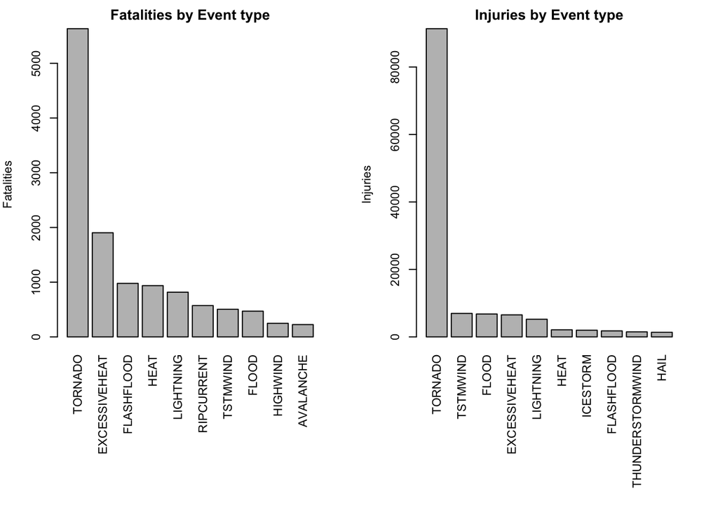

```r
require(ggplot2)
par(mfrow=c(1, 2), mar = c(12, 4, 2, 2.5), cex=0.7)
barplot(top.fatal$total.fatalities, names.arg=top.fatal$EVTYPE3, ylab='Fatalities', las=3,
        main='Fatalities by Event type')
barplot(top.injuries$total.injuries, names.arg=top.injuries$EVTYPE3, ylab='Injuries', las=3,
        main='Injuries by Event type')
```

### Most harmful with respect to the economy

Next, we look at the cost of these events to the economy. We look at both property damage and damage to crops:

```r
property <- noaa3 %>% group_by(EVTYPE3) %>% summarize(total.property.damage=sum(property.damage)) %>%
    arrange(desc(total.property.damage))
top.property <- head(property, n=10)
top.property
```

```
## Source: local data frame [10 x 2]
##
##             EVTYPE3 total.property.damage
##               (chr)                 (dbl)
## 1             FLOOD          144657709807
## 2  HURRICANETYPHOON           69305840000
## 3           TORNADO           56952151876
## 4        STORMSURGE           43323536000
## 5        FLASHFLOOD           16823223978
## 6              HAIL           15735819513
## 7         HURRICANE           11868319010
## 8     TROPICALSTORM            7703890550
## 9       WINTERSTORM            6688497251
## 10         WILDFIRE            5489714000
```

```r
crop <- noaa3 %>% group_by(EVTYPE3) %>% summarize(total.crop.damage=sum(crop.damage)) %>%
    arrange(desc(total.crop.damage))
top.crop <- head(crop, n=10)
top.crop
```

```
## Source: local data frame [10 x 2]
##
##                   EVTYPE3 total.crop.damage
##                     (chr)             (dbl)
## 1               HURRICANE      802881916053
## 2        HURRICANETYPHOON      732768451330
## 3                   FLOOD       87251978368
## 4              FLASHFLOOD       38865139889
## 5                 TORNADO       28269885712
## 6                    HAIL       15316833978
## 7  HURRICANEOPALHIGHWINDS       10000000000
## 8                TSTMWIND        7684657862
## 9                WILDFIRE        7174309478
## 10               HIGHWIND        7174066263
```

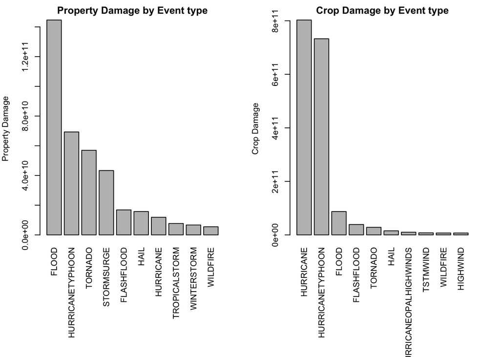

```r
require(ggplot2)

par(mfrow=c(1, 2), mar = c(12, 4, 2, 2.5), cex=0.7)
barplot(top.property$total.property.damage, names.arg=top.property$EVTYPE3, ylab='Property Damage', las=3,
        main='Property Damage by Event type')
barplot(top.crop$total.crop.damage, names.arg=top.crop$EVTYPE3, ylab='Crop Damage', las=3,
        main='Crop Damage by Event type')
```

We can see that `HURRICANE` and `HURRICANETYPHOON` are both the most harmful event types for crops. These probably could even be lumped into a single event type `HURRICANE` (see data cleaning section).

We can also see that `FLOOD` causes the most property damage, with `HURRICANETYPHOON` and `TORNADO` among the top 3 too!

I would be interested in seeing how much these numbers change if I had time to reassign each event type to a smaller list (say, 20-30 types) by doing a more rigorous data cleaning. I do not really think the #1’s will change, though.